# Connecticut Home Value Trends: 2018–2025 Analysis

Ryan Mannix

2025-07-27

## Introduction

This report analyzes Connecticut county-level home values for single-family homes and condos, comparing pre-, during-, and post-COVID periods (2018–2025). Data is from Zillow’s ZHVI dataset.

Data Source: https://www.zillow.com/research/data

Note: This data was downloaded on June 27, 2025, so average 2025 home values reflect figures up to that date.

## 📁 Load and Filter Data

```r
# Read in the Zillow Home Value Index (ZHVI) datasets for Single Family and Condo homes
sfr_frame <- read.csv("County_zhvi_uc_sfr_tier_0.33_0.67_sm_sa_month.csv")
condo_frame <- read.csv("County_zhvi_uc_condo_tier_0.33_0.67_sm_sa_month.csv")

# Filter data to only include Connecticut counties
sfr_frame <- sfr_frame %>% filter(State == "CT")
condo_frame <- condo_frame %>% filter(State == "CT")
```

## 📊 Calculate Yearly Averages

```r
# Create new columns for each year by averaging monthly values
# Use [[ ]] to dynamically assign to columns named "2018", "2019", ..., "2025"
years <- 2018:2025

for(year in years) {
  sfr_frame[[as.character(year)]] <- rowMeans(select(sfr_frame, contains(paste0("X", year))))
  condo_frame[[as.character(year)]] <- rowMeans(select(condo_frame, contains(paste0("X", year))))
}

# Keep only relevant columns for analysis
sfr_frame <- sfr_frame %>% select(State, RegionName, MunicipalCodeFIPS, all_of(as.character(years)))
condo_frame <- condo_frame %>% select(State, RegionName, MunicipalCodeFIPS, all_of(as.character(years)))
```

## 📈 Trend Over Time – Single-Family Residences

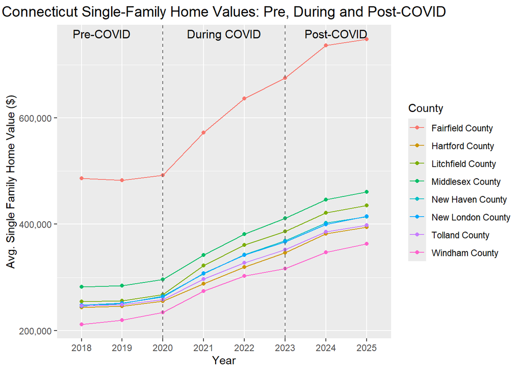

```r
# Convert data to long format for plotting
sfr_frame_long <- sfr_frame %>%
  pivot_longer(cols = contains("20"), names_to = "Year", values_to = "Average_Home_Values") %>%
  mutate(Year = factor(Year,levels = as.character(2018:2025))) %>% # Factored to preserve correct order in plot
  arrange(RegionName, Year)

# Trend over time plot
ggplot( sfr_frame_long, aes(x=Year, y=Average_Home_Values, colour = RegionName, group = RegionName)) +
         geom_line() +
         geom_point() +
         labs(title = "Connecticut Single-Family Home Values: Pre, During and Post-COVID", x= "Year", y = "Avg. Single Family Home Value ($)", colour= "County") +
         scale_y_continuous(labels = label_comma()) + # Format Y axis with commas - Not Scientific Notation
         geom_vline(xintercept = which(levels(sfr_frame_long$Year) %in% c("2020", "2023")), linetype= "dashed", colour= "gray40") + # Mark start/end of COVID period
         annotate("text", x=1.5, y=Inf, label= "Pre-COVID", vjust= 1.5, size = 4) +
         annotate("text", x=4.5, y=Inf, label= "During COVID", vjust= 1.5, size = 4) +
         annotate("text", x=7.25, y=Inf, label= "Post-COVID", vjust= 1.5, size = 4) +
         theme(plot.title = element_text(hjust = 0.5, size = 14))
```

**Single-Family Trends Plot**  
* **Fairfield County** stands out, with 2025 average home values almost $300,000 higher than any other county in Connecticut.  
* Home values rose steadily across all counties from **2020 to 2025**.

## 📋 Table – Percent Increase in Single-Family Values

```r
# Calculate percent increase from 2018 to 2025 for SFR
Home_Value_Percent_Increase_Table <- sfr_frame %>%
  mutate(Delta_Price = `2025` - `2018`,
         Percent_Increase = round(((`2025` - `2018`) / `2018`) * 100)) %>%
  select(RegionName,`2018`, `2025`, Delta_Price, Percent_Increase) %>%
  arrange(-Percent_Increase) #Sort by highest increase

# Display the result in a formulated table using gt
Home_Value_Percent_Increase_Table %>%
  gt() %>%
  cols_align(align = "center", columns = everything()) %>%
  cols_label(
    `2018` = md("**2018 Avg. Home Price ($)**"),
    `2025` = md("**2025 Avg. Home Price ($)**"),
    Delta_Price = md("**Price Increase ($)**"),
    RegionName = md("**County**"),
    Percent_Increase = md("**Percent Increase (%)**")
  ) %>%
  tab_header(title = md("**Percent Increase in Average Single-Family Home Prices (2018-2025)**")) %>%
  tab_style(
    style = cell_borders(sides = "all", color = "black", weight = px(1.5)),
    locations=cells_body()
  )
```

**Percent Increase in Average Single-Family Home Prices (2018-2025)**

| **County** | **2018 Avg. Home Price ($)** | **2025 Avg. Home Price ($)** | **Price Increase ($)** | **Percent Increase (%)** |
| --- | --- | --- | --- | --- |
| Litchfield County | 254520.3 | 435067.0 | 180546.7 | 71 |
| Windham County | 211888.5 | 362937.8 | 151049.3 | 71 |
| New Haven County | 245673.2 | 414148.3 | 168475.1 | 69 |
| New London County | 248132.2 | 414567.9 | 166435.7 | 67 |
| Middlesex County | 282020.0 | 460935.3 | 178915.3 | 63 |
| Hartford County | 243776.3 | 394179.4 | 150403.1 | 62 |
| Tolland County | 246818.1 | 398353.5 | 151535.4 | 61 |
| Fairfield County | 486487.4 | 748105.7 | 261618.3 | 54 |

**Single-Family Percent Increase Table**  
* **Litchfield & Windham** county led with a **71% increase**, followed by **New Haven** at **69%**.  
* Every county gained over **$150,000** in average home value between **2018 and 2025**.

## 📊 Bar Chart – Single-Family Home Value Increase

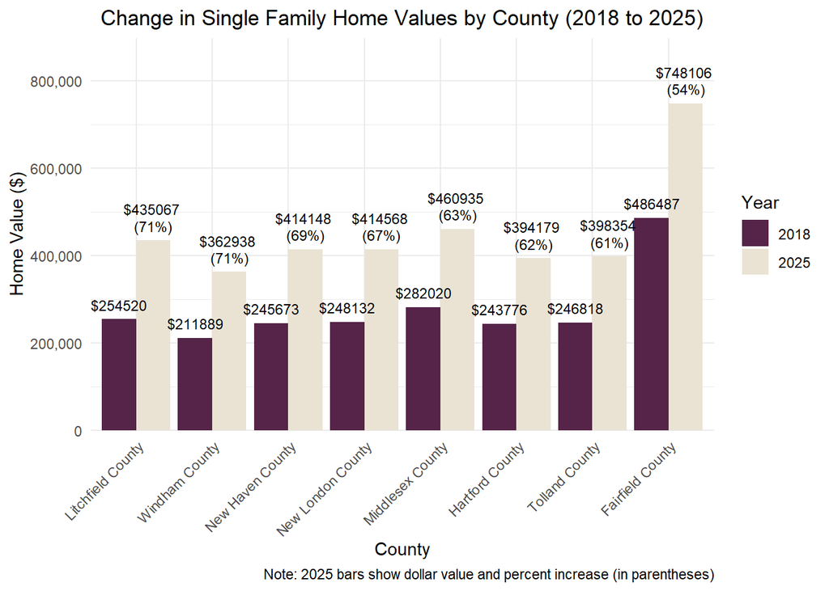

```r
# Long format for chart
sfr_long <- Home_Value_Percent_Increase_Table %>%
  pivot_longer(cols = c(`2018`, `2025`), names_to = "Year", values_to = "Average_Home_Values") %>%
  mutate(
    Bar_Chart_Format_Col = case_when(
      Year == "2025" ~ paste0("$", round(Average_Home_Values), " <br> ", "(", Percent_Increase, "%)"),
      Year == "2018" ~ paste0("$", round(Average_Home_Values))
    )
  )

# Bar chart
ggplot(sfr_long, aes(x= reorder(RegionName,-Percent_Increase), y=Average_Home_Values, fill = Year)) +
  geom_col(position = position_dodge(width = 0.9)) +
  labs(title = "Change in Single Family Home Values by County (2018 to 2025)",
    x= "County",
    y= "Home Value ($)",
    caption = "Note: 2025 bars show dollar value and percent increase (in parentheses)") +
  scale_y_continuous(labels = label_comma(), expand = expansion(mult = c(0, 0.2))) + #expanded y axis to include labels
  scale_fill_manual(values = c("2018" = "#552448", "2025"= "#eae3d4")) +
  ggtext::geom_richtext(
    aes(label = Bar_Chart_Format_Col, group = Year),
    position = position_dodge(width = 0.9), vjust= 0, size = 3,
    fill = NA, label.color = NA
  ) +
  theme_minimal() +
  theme(
    axis.text.x = element_text(angle=45, hjust= 1),
    plot.title = element_text(hjust = 0.5) # center plot title
  )
```

**Single-Family Bar Chart**  
* *All counties showed growth above 50%*, indicating broad-based appreciation.  
* **Fairfield County** average home values in 2025 have increased the most since 2018 with an **increase of $262,000**.

## 📈 Trend Over Time – Condos

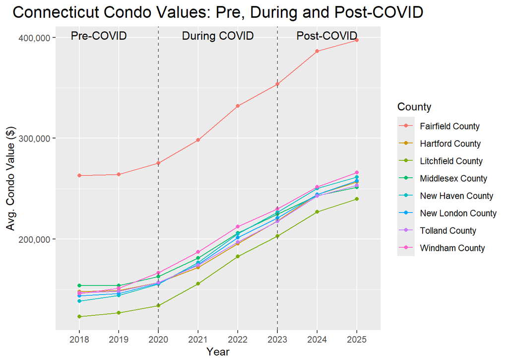

```r
# Convert data to long format for plotting
condo_frame_long <- condo_frame %>%
  pivot_longer(cols = contains("20"), names_to = "Year", values_to = "Average_Home_Values") %>%
  mutate(Year = factor(Year,levels = as.character(2018:2025))) %>% # Factored to preserve correct order in plot
  arrange(RegionName, Year)

# Trend over time plot
ggplot( condo_frame_long, aes(x=Year, y=Average_Home_Values, colour = RegionName, group = RegionName)) +
         geom_line() +
         geom_point() +
         labs(title = "Connecticut Condo Values: Pre, During and Post-COVID", x= "Year", y = "Avg. Condo Value ($)", colour= "County") +
         scale_y_continuous(labels = label_comma()) + # Format Y axis with commas - not scientific notation
         geom_vline(xintercept = which(levels(sfr_frame_long$Year) %in% c("2020", "2023")), linetype= "dashed", colour= "gray40") + # Mark start/end of COVID period
         annotate("text", x=1.5, y=Inf, label= "Pre-COVID", vjust= 1.5, size = 4) +
         annotate("text", x=4.5, y=Inf, label= "During COVID", vjust= 1.5, size = 4) +
         annotate("text", x=7.25, y=Inf, label= "Post-COVID", vjust= 1.5, size = 4) +
         theme(plot.title = element_text(hjust = 0.5, size = 16))
```

**Condo Trends Plot**  
* Again **Fairfield County** stands out, with 2025 average condo values over **$130,000 higher** than any other county in Connecticut.  
* Average condo values rose sharply from **2020 to 2025**.

## 📋 Table – Condo Price Increase

```r
# Calculate percent increase from 2018 to 2025 for condos
Condo_Value_Percent_Increase_Table <- condo_frame %>%
  mutate(Delta_Price = `2025` - `2018`,
         Percent_Increase = round(((`2025` - `2018`) / `2018`) * 100)) %>%
  select(RegionName,`2018`, `2025`, Delta_Price, Percent_Increase) %>%
  arrange(-Percent_Increase) #Sort by highest increase

# Display the result in a formulated table using gt
  gt(Condo_Value_Percent_Increase_Table) %>%
  cols_align(align = "center", columns = everything()) %>%
  cols_label(
    `2018` = md("**2018 Avg. Condo Price ($)**"),
    `2025` = md("**2025 Avg. Condo Price ($)**"),
    Delta_Price = md("**Price Increase ($)**"),
    RegionName = md("**County**"),
    Percent_Increase = md("**Percent Increase (%)**")
  ) %>%
  tab_header(title = md("**Condo Value Increase (2018-2025)**")) %>%
  tab_style(
    style = cell_borders(sides = "all", color = "black", weight = px(1.5)),
    locations=cells_body()
  )
```

**Condo Value Increase (2018-2025)**

| **County** | **2018 Avg. Condo Price ($)** | **2025 Avg. Condo Price ($)** | **Price Increase ($)** | **Percent Increase (%)** |
| --- | --- | --- | --- | --- |
| Litchfield County | 123213.2 | 239816.0 | 116602.79 | 95 |
| New Haven County | 138569.3 | 261619.0 | 123049.69 | 89 |
| Windham County | 146171.8 | 265885.5 | 119713.69 | 82 |
| New London County | 143628.0 | 257907.9 | 114279.83 | 80 |
| Hartford County | 148098.9 | 256681.7 | 108582.77 | 73 |
| Tolland County | 146908.7 | 253386.0 | 106477.32 | 72 |
| Middlesex County | 153875.4 | 251431.3 | 97555.95 | 63 |
| Fairfield County | 262862.2 | 397200.6 | 134338.36 | 51 |

**Condo Value Increase Table**  
* **Litchfield County** saw the largest increase in condo values, up **95%** since 2018.  
* **New Haven** followed closely with a **89% increase**.  
* Most counties gained over **$100,000** in average condo value between 2018 and 2025.

## 📊 Bar Chart – Condo Price Increase

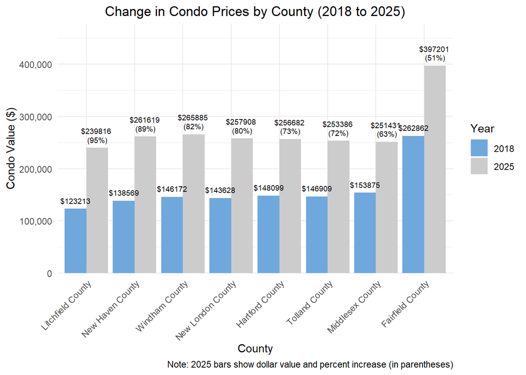

```r
# Long format for chart
condo_long <- Condo_Value_Percent_Increase_Table %>%
  pivot_longer(cols = c(`2018`, `2025`), names_to = "Year", values_to = "Average_Condo_Values") %>%
  mutate(
    Bar_Chart_Format_Col = case_when(
      Year == "2025" ~ paste0("$", round(Average_Condo_Values), " <br> ", "(", Percent_Increase, "%)"),
      Year == "2018" ~ paste0("$", round(Average_Condo_Values))
    )
  )

#Bar chart
ggplot(condo_long, aes(x= reorder(RegionName,-Percent_Increase), y=Average_Condo_Values, fill = Year)) +
  geom_col(position = position_dodge(width = 0.9)) +
  labs(
    title = "Change in Condo Prices by County (2018 to 2025)",
    x= "County",
    y= "Condo Value ($)",
    caption = "Note: 2025 bars show dollar value and percent increase (in parentheses)") +
  scale_y_continuous(labels = label_comma(), expand = expansion(mult = c(0, 0.2))) + #expanded y axis to include labels
  scale_fill_manual(values = c("2018" = "#6fa8dd", "2025"= "#cccccc")) +
  ggtext::geom_richtext(
    aes(label = Bar_Chart_Format_Col, group = Year),
    position = position_dodge(width = 0.9), vjust= 0, size = 2.5,
    fill = NA, label.color = NA
  ) +
  theme_minimal() +
  theme(
    axis.text.x = element_text(angle=45, hjust= 1),
    plot.title = element_text(hjust = 0.5) # center plot title
  )
```

**Condo Bar Chart**  
* **Fairfield** county average home values in 2025 have increased the most since 2018 with an increase of $134,000.  
* *All counties showed growth above 50%*, indicating broad-based appreciation.  
* Counties with lower 2018 prices (e.g., **Litchfield**, **New Haven**) saw the largest **percentage increases**.

## 🏠📈 Condo vs. Single-Family Home Value Growth Comparison

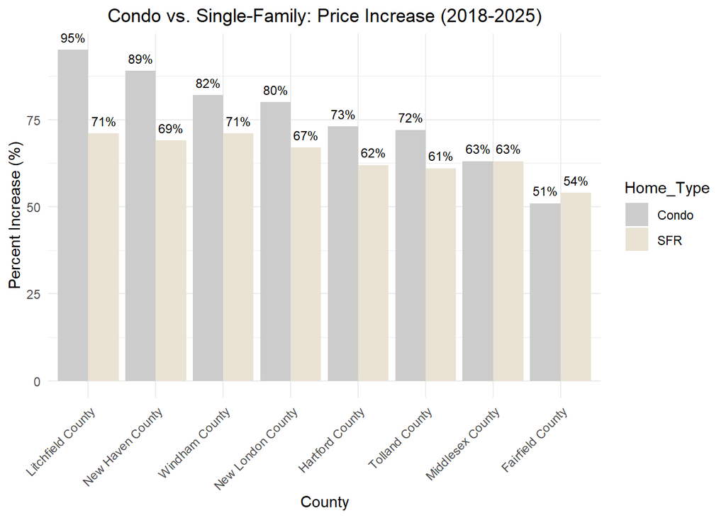

```r
# Join sfr and condo tables
condo_vs_sfr <- Home_Value_Percent_Increase_Table %>%
  left_join(Condo_Value_Percent_Increase_Table, by= "RegionName") %>%
  select(RegionName, Percent_Increase.x, Percent_Increase.y)

# Rename columns
condo_vs_sfr <- condo_vs_sfr %>%
  rename(County = RegionName, SFR = Percent_Increase.x, Condo = Percent_Increase.y)

# Long format for bar chart
condo_vs_sfr_Percent_Increase_long <- condo_vs_sfr %>% pivot_longer(cols = contains(c("SFR","Condo")), names_to = "Home_Type", values_to = "Percent_Increase")

# Comparison bar chart
condo_vs_sfr_Percent_Increase_long %>% ggplot(aes(x= reorder(County,-Percent_Increase), y=Percent_Increase, fill = Home_Type)) +
  geom_col(position = position_dodge(width = 0.9)) +
  labs(title = "Condo vs. Single-Family: Price Increase (2018-2025)",
       x= "County",
       y= "Percent Increase (%)") +
  scale_y_continuous(labels = label_comma()) +
  scale_fill_manual(values = c("SFR" = "#eae3d4", "Condo" = "#cccccc")) +
  ggtext::geom_richtext(
    aes(label = paste0(Percent_Increase,"%"), group = Home_Type),
    position = position_dodge(width = 0.9), vjust= 0, size = 3,
    fill = NA, label.color = NA
  ) +
  theme_minimal() +
  theme(
    axis.text.x = element_text(angle=45, hjust= 1),
    plot.title = element_text(hjust = 0.5) # center plot title
  )
```

**Condo vs. Single-Family Comparison Bar Chart**  
* For most Connecticut counties, condos outpaced single-family homes in **percentage growth**.  
* The largest growth gaps appeared in counties like **Litchfield** and **New Haven**,  
where condos outperformed single family residences (SFR) by **20+ percentage points**.  
* This highlights **affordability-driven demand** and shifting buyer behavior post-COVID.

## 📌 Summary Statistics (2018–2025)

```r
# Summary statistics for Single-Family Residences
sfr_summary <- Home_Value_Percent_Increase_Table %>%
  summarise(
    Mean_2018 = mean(`2018`),
    Mean_2025 = mean(`2025`),
    Avg_Percent_Increase = round(mean(Percent_Increase), 0),
    Max_Percent_Increase = max(Percent_Increase),
    Min_Percent_Increase = min(Percent_Increase)
  )
# Summary statistics for Condos
condo_summary <- Condo_Value_Percent_Increase_Table %>%
  summarise(
    Mean_2018 = mean(`2018`),
    Mean_2025 = mean(`2025`),
    Avg_Percent_Increase = round(mean(Percent_Increase), 0),
    Max_Percent_Increase = max(Percent_Increase),
    Min_Percent_Increase = min(Percent_Increase)
  )

# Combine for comparison
summary_stats <- bind_rows( # Binds sfr and condo summaries together and adds a column of Home_Type
  sfr_summary %>% mutate(Home_Type = "Single-Family"),
  condo_summary %>% mutate(Home_Type = "Condo")
  ) %>%
  select(Home_Type, everything()) %>% #selects to put Home_Type first
  mutate(
    Mean_2018 = dollar(Mean_2018),# adds $ in front
    Mean_2025 = dollar(Mean_2025),
    Avg_Percent_Increase = paste0(Avg_Percent_Increase, "%"), #adding % in back
    Max_Percent_Increase = paste0(Max_Percent_Increase, "%"),
    Min_Percent_Increase = paste0(Min_Percent_Increase, "%")
  )

# Display as a table
gt(summary_stats) %>%
  cols_label(
    Home_Type = "Home Type",
    Mean_2018 = "Avg. Value (2018)",
    Mean_2025 = "Avg. Value (2025)",
    Avg_Percent_Increase = "Mean % Increase",
    Max_Percent_Increase = "Max % Increase",
    Min_Percent_Increase = "Min % Increase"
    ) %>%
  tab_header(
    title = md("**Summary Statistics of Home Value Changes (2018–2025)**")
  ) %>%
  cols_align(align = "center", columns = everything()) %>%
  tab_style(
    style = cell_borders(sides = "all", color = "black", weight = px(1.5)),
    locations=cells_body()
  )
```

**Summary Statistics of Home Value Changes (2018–2025)**

| Home Type | Avg. Value (2018) | Avg. Value (2025) | Mean % Increase | Max % Increase | Min % Increase |
| --- | --- | --- | --- | --- | --- |
| Single-Family | $277,415 | $453,537 | 65% | 71% | 54% |
| Condo | $157,916 | $272,991 | 76% | 95% | 51% |

## 🧾 **Conclusion**

Between 2018 and 2025, Connecticut’s housing market experienced strong appreciation across both single-family homes and condos, with **condos slightly outpacing single-family homes** in average percentage growth.

### 🏡 **Single-Family Residences**

- Average value rose from **$277,415** to **$453,537**, a **65% increase** statewide.
- Growth ranged from **54% to 71%**, showing relatively consistent appreciation across counties.
- This trend suggests continued demand for suburban and rural living, likely accelerated by COVID-era preferences for more space and lower-density environments.

### 🏢 **Condominiums**

- Average value increased from **$157,916** to **$272,991**, a **76% increase** overall.
- Growth varied more widely—**51% to 95%**, depending on county.
- Higher average growth may reflect rising condo appeal due to **affordability constraints**, **changing lifestyle needs**, and more **first-time buyers or downsizers** entering the market.

### 📌 **Final Insights**

- Condos **outpaced single-family homes** in percent growth (**76% vs. 65%**), despite starting from a lower value base.
- The **COVID period (2020–2023)** marked a clear inflection point for home value acceleration.
- Some counties saw **condo values nearly double**, with a max growth of **95%**.

These findings highlight a **resilient and evolving housing market** in Connecticut. For **investors, planners, and homeowners**, understanding these dynamics is essential for future real estate strategy and decision-making.